# GtkListBox

GtkListBox — A list container

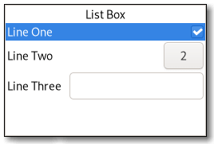

## Functions

| gboolean | (*GtkListBoxFilterFunc) () |
| --- | --- |
| int | (*GtkListBoxSortFunc) () |
| void | (*GtkListBoxUpdateHeaderFunc) () |
| GtkWidget * | gtk_list_box_new () |
| void | gtk_list_box_prepend () |
| void | gtk_list_box_append () |
| void | gtk_list_box_insert () |
| void | gtk_list_box_remove () |
| void | gtk_list_box_select_row () |
| void | gtk_list_box_unselect_row () |
| void | gtk_list_box_select_all () |
| void | gtk_list_box_unselect_all () |
| GtkListBoxRow * | gtk_list_box_get_selected_row () |
| void | (*GtkListBoxForeachFunc) () |
| void | gtk_list_box_selected_foreach () |
| GList * | gtk_list_box_get_selected_rows () |
| void | gtk_list_box_set_show_separators () |
| gboolean | gtk_list_box_get_show_separators () |
| void | gtk_list_box_set_selection_mode () |
| GtkSelectionMode | gtk_list_box_get_selection_mode () |
| void | gtk_list_box_set_activate_on_single_click () |
| gboolean | gtk_list_box_get_activate_on_single_click () |
| GtkAdjustment * | gtk_list_box_get_adjustment () |
| void | gtk_list_box_set_adjustment () |
| void | gtk_list_box_set_placeholder () |
| GtkListBoxRow * | gtk_list_box_get_row_at_index () |
| GtkListBoxRow * | gtk_list_box_get_row_at_y () |
| void | gtk_list_box_invalidate_filter () |
| void | gtk_list_box_invalidate_headers () |
| void | gtk_list_box_invalidate_sort () |
| void | gtk_list_box_set_filter_func () |
| void | gtk_list_box_set_header_func () |
| void | gtk_list_box_set_sort_func () |
| void | gtk_list_box_drag_highlight_row () |
| void | gtk_list_box_drag_unhighlight_row () |
| GtkWidget * | (*GtkListBoxCreateWidgetFunc) () |
| void | gtk_list_box_bind_model () |
| GtkWidget * | gtk_list_box_row_new () |
| void | gtk_list_box_row_changed () |
| gboolean | gtk_list_box_row_is_selected () |
| GtkWidget * | gtk_list_box_row_get_child () |
| void | gtk_list_box_row_set_child () |
| GtkWidget * | gtk_list_box_row_get_header () |
| void | gtk_list_box_row_set_header () |
| int | gtk_list_box_row_get_index () |
| void | gtk_list_box_row_set_activatable () |
| gboolean | gtk_list_box_row_get_activatable () |
| void | gtk_list_box_row_set_selectable () |
| gboolean | gtk_list_box_row_get_selectable () |

## Properties

| gboolean | accept-unpaired-release | Read / Write |
| --- | --- | --- |
| gboolean | activate-on-single-click | Read / Write |
| GtkSelectionMode | selection-mode | Read / Write |
| gboolean | show-separators | Read / Write |
| gboolean | activatable | Read / Write |
| GtkWidget * | child | Read / Write |
| gboolean | selectable | Read / Write |

## Signals

| void | activate-cursor-row | Action |
| --- | --- | --- |
| void | move-cursor | Action |
| void | row-activated | Run Last |
| void | row-selected | Run Last |
| void | select-all | Action |
| void | selected-rows-changed | Run First |
| void | toggle-cursor-row | Action |
| void | unselect-all | Action |
| void | activate | Action |

## Types and Values

|  | GtkListBox |
| --- | --- |
| struct | GtkListBoxRow |
| struct | GtkListBoxRowClass |

## Object Hierarchy

```
    GObject
    ╰── GInitiallyUnowned
        ╰── GtkWidget
            ├── GtkListBox
            ╰── GtkListBoxRow
```

## Implemented Interfaces

GtkListBox implements GtkAccessible, GtkBuildable and GtkConstraintTarget.

GtkListBoxRow implements GtkAccessible, GtkBuildable, GtkConstraintTarget and GtkActionable.

## Includes

```
#include <gtk/gtk.h>
```

## Description

A GtkListBox is a vertical container that contains GtkListBoxRow children. These rows can by dynamically sorted and filtered, and headers can be added dynamically depending on the row content. It also allows keyboard and mouse navigation and selection like a typical list.

Using GtkListBox is often an alternative to GtkTreeView, especially when the list contents has a more complicated layout than what is allowed by a GtkCellRenderer, or when the contents is interactive (i.e. has a button in it).

Although a GtkListBox must have only GtkListBoxRow children you can add any kind of widget to it via `gtk_list_box_prepend()`, `gtk_list_box_append()` and `gtk_list_box_insert()` and a GtkListBoxRow widget will automatically be inserted between the list and the widget.

GtkListBoxRows can be marked as activatable or selectable. If a row is activatable, “row-activated” will be emitted for it when the user tries to activate it. If it is selectable, the row will be marked as selected when the user tries to select it.

### GtkListBox as GtkBuildable

The GtkListBox implementation of the GtkBuildable interface supports setting a child as the placeholder by specifying “placeholder” as the “type” attribute of a <child> element. See `gtk_list_box_set_placeholder()` for info.

### CSS nodes

```
list[.separators][.rich-list][.navigation-sidebar]
╰── row[.activatable]
```

GtkListBox uses a single CSS node named list. It may carry the .separators style class, when the “show-separators” property is set. Each GtkListBoxRow uses a single CSS node named row. The row nodes get the .activatable style class added when appropriate.

The main list node may also carry style classes to select the style of list presentation: .rich-list, .navigation-sidebar or .data-table.

### Accessibility

GtkListBox uses the GTK_ACCESSIBLE_ROLE_LIST role and GtkListBoxRow uses the GTK_ACCESSIBLE_ROLE_LIST_ITEM role.

## Functions

### GtkListBoxFilterFunc ()

```
gboolean
(*GtkListBoxFilterFunc) (GtkListBoxRow *row,
                         gpointer user_data);
```

Will be called whenever the row changes or is added and lets you control if the row should be visible or not.

#### Parameters

| row | the row that may be filtered |  |
| --- | --- | --- |
| user_data | user data. | [closure] |

#### Returns

`TRUE` if the row should be visible, `FALSE` otherwise

### GtkListBoxSortFunc ()

```
int
(*GtkListBoxSortFunc) (GtkListBoxRow *row1,
                       GtkListBoxRow *row2,
                       gpointer user_data);
```

Compare two rows to determine which should be first.

#### Parameters

| row1 | the first row |  |
| --- | --- | --- |
| row2 | the second row |  |
| user_data | user data. | [closure] |

#### Returns

< 0 if *`row1`* should be before *`row2`* , 0 if they are equal and > 0 otherwise

### GtkListBoxUpdateHeaderFunc ()

```
void
(*GtkListBoxUpdateHeaderFunc) (GtkListBoxRow *row,
                               GtkListBoxRow *before,
                               gpointer user_data);
```

Whenever *`row`* changes or which row is before *`row`* changes this is called, which lets you update the header on *`row`* . You may remove or set a new one via `gtk_list_box_row_set_header()` or just change the state of the current header widget.

#### Parameters

| row | the row to update |  |
| --- | --- | --- |
| before | the row before *`row`* , or `NULL` if it is first. | [allow-none] |
| user_data | user data. | [closure] |

### gtk_list_box_new ()

```
GtkWidget *
gtk_list_box_new (void);
```

Creates a new GtkListBox container.

#### Returns

a new GtkListBox

### gtk_list_box_prepend ()

```
void
gtk_list_box_prepend (GtkListBox *box,
                      GtkWidget *child);
```

Prepend a widget to the list. If a sort function is set, the widget will actually be inserted at the calculated position.

#### Parameters

| box | a GtkListBox |  |
| --- | --- | --- |
| child | the GtkWidget to add |  |

### gtk_list_box_append ()

```
void
gtk_list_box_append (GtkListBox *box,
                     GtkWidget *child);
```

Append a widget to the list. If a sort function is set, the widget will actually be inserted at the calculated position.

#### Parameters

| box | a GtkListBox |  |
| --- | --- | --- |
| child | the GtkWidget to add |  |

### gtk_list_box_insert ()

```
void
gtk_list_box_insert (GtkListBox *box,
                     GtkWidget *child,
                     int position);
```

Insert the *`child`* into the *`box`* at *`position`* . If a sort function is set, the widget will actually be inserted at the calculated position.

If *`position`* is -1, or larger than the total number of items in the *`box`* , then the *`child`* will be appended to the end.

#### Parameters

| box | a GtkListBox |  |
| --- | --- | --- |
| child | the GtkWidget to add |  |
| position | the position to insert *`child`* in |  |

### gtk_list_box_remove ()

```
void
gtk_list_box_remove (GtkListBox *box,
                     GtkWidget *child);
```

Removes a child from *`box`* .

#### Parameters

| box | a GtkListBox |  |
| --- | --- | --- |
| child | the child to remove |  |

### gtk_list_box_select_row ()

```
void
gtk_list_box_select_row (GtkListBox *box,
                         GtkListBoxRow *row);
```

Make *`row`* the currently selected row.

#### Parameters

| box | a GtkListBox |  |
| --- | --- | --- |
| row | The row to select or `NULL`. | [allow-none] |

### gtk_list_box_unselect_row ()

```
void
gtk_list_box_unselect_row (GtkListBox *box,
                           GtkListBoxRow *row);
```

Unselects a single row of *`box`* , if the selection mode allows it.

#### Parameters

| box | a GtkListBox |  |
| --- | --- | --- |
| row | the row to unselected |  |

### gtk_list_box_select_all ()

```
void
gtk_list_box_select_all (GtkListBox *box);
```

Select all children of *`box`* , if the selection mode allows it.

#### Parameters

| box | a GtkListBox |  |
| --- | --- | --- |

### gtk_list_box_unselect_all ()

```
void
gtk_list_box_unselect_all (GtkListBox *box);
```

Unselect all children of *`box`* , if the selection mode allows it.

#### Parameters

| box | a GtkListBox |  |
| --- | --- | --- |

### gtk_list_box_get_selected_row ()

```
GtkListBoxRow *
gtk_list_box_get_selected_row (GtkListBox *box);
```

Gets the selected row.

Note that the box may allow multiple selection, in which case you should use `gtk_list_box_selected_foreach()` to find all selected rows.

#### Parameters

| box | a GtkListBox |  |
| --- | --- | --- |

#### Returns

the selected row.

[transfer none]

### GtkListBoxForeachFunc ()

```
void
(*GtkListBoxForeachFunc) (GtkListBox *box,
                          GtkListBoxRow *row,
                          gpointer user_data);
```

A function used by `gtk_list_box_selected_foreach()`. It will be called on every selected child of the *`box`* .

#### Parameters

| box | a GtkListBox |  |
| --- | --- | --- |
| row | a GtkListBoxRow |  |
| user_data | user data. | [closure] |

### gtk_list_box_selected_foreach ()

```
void
gtk_list_box_selected_foreach (GtkListBox *box,
                               GtkListBoxForeachFunc func,
                               gpointer data);
```

Calls a function for each selected child.

Note that the selection cannot be modified from within this function.

#### Parameters

| box | a GtkListBox |  |
| --- | --- | --- |
| func | the function to call for each selected child. | [scope call] |
| data | user data to pass to the function |  |

### gtk_list_box_get_selected_rows ()

```
GList *
gtk_list_box_get_selected_rows (GtkListBox *box);
```

Creates a list of all selected children.

#### Parameters

| box | a GtkListBox |  |
| --- | --- | --- |

#### Returns

A GList containing the GtkWidget for each selected child. Free with `g_list_free()` when done.

[element-type GtkListBoxRow][transfer container]

### gtk_list_box_set_show_separators ()

```
void
gtk_list_box_set_show_separators (GtkListBox *box,
                                  gboolean show_separators);
```

Sets whether the list box should show separators between rows.

#### Parameters

| box | a GtkListBox |  |
| --- | --- | --- |
| show_separators | `TRUE` to show separators |  |

### gtk_list_box_get_show_separators ()

```
gboolean
gtk_list_box_get_show_separators (GtkListBox *box);
```

Returns whether the list box should show separators between rows.

#### Parameters

| box | a GtkListBox |  |
| --- | --- | --- |

#### Returns

`TRUE` if the list box shows separators

### gtk_list_box_set_selection_mode ()

```
void
gtk_list_box_set_selection_mode (GtkListBox *box,
                                 GtkSelectionMode mode);
```

Sets how selection works in the listbox. See GtkSelectionMode for details.

#### Parameters

| box | a GtkListBox |  |
| --- | --- | --- |
| mode | The GtkSelectionMode |  |

### gtk_list_box_get_selection_mode ()

```
GtkSelectionMode
gtk_list_box_get_selection_mode (GtkListBox *box);
```

Gets the selection mode of the listbox.

#### Parameters

| box | a GtkListBox |  |
| --- | --- | --- |

#### Returns

a GtkSelectionMode

### gtk_list_box_set_activate_on_single_click ()

```
void
gtk_list_box_set_activate_on_single_click
                               (GtkListBox *box,
                                gboolean single);
```

If *`single`* is `TRUE`, rows will be activated when you click on them, otherwise you need to double-click.

#### Parameters

| box | a GtkListBox |  |
| --- | --- | --- |
| single | a boolean |  |

### gtk_list_box_get_activate_on_single_click ()

```
gboolean
gtk_list_box_get_activate_on_single_click
                               (GtkListBox *box);
```

Returns whether rows activate on single clicks.

#### Parameters

| box | a GtkListBox |  |
| --- | --- | --- |

#### Returns

`TRUE` if rows are activated on single click, `FALSE` otherwise

### gtk_list_box_get_adjustment ()

```
GtkAdjustment *
gtk_list_box_get_adjustment (GtkListBox *box);
```

Gets the adjustment (if any) that the widget uses to for vertical scrolling.

#### Parameters

| box | a GtkListBox |  |
| --- | --- | --- |

#### Returns

the adjustment.

[transfer none]

### gtk_list_box_set_adjustment ()

```
void
gtk_list_box_set_adjustment (GtkListBox *box,
                             GtkAdjustment *adjustment);
```

Sets the adjustment (if any) that the widget uses to for vertical scrolling. For instance, this is used to get the page size for PageUp/Down key handling.

In the normal case when the *`box`* is packed inside a GtkScrolledWindow the adjustment from that will be picked up automatically, so there is no need to manually do that.

#### Parameters

| box | a GtkListBox |  |
| --- | --- | --- |
| adjustment | the adjustment, or `NULL`. | [allow-none] |

### gtk_list_box_set_placeholder ()

```
void
gtk_list_box_set_placeholder (GtkListBox *box,
                              GtkWidget *placeholder);
```

Sets the placeholder widget that is shown in the list when it doesn't display any visible children.

#### Parameters

| box | a GtkListBox |  |
| --- | --- | --- |
| placeholder | a GtkWidget or `NULL`. | [allow-none] |

### gtk_list_box_get_row_at_index ()

```
GtkListBoxRow *
gtk_list_box_get_row_at_index (GtkListBox *box,
                               int index_);
```

Gets the n-th child in the list (not counting headers). If *`_index`* is negative or larger than the number of items in the list, `NULL` is returned.

#### Parameters

| box | a GtkListBox |  |
| --- | --- | --- |
| index_ | the index of the row |  |

#### Returns

the child GtkWidget or `NULL`.

[transfer none][nullable]

### gtk_list_box_get_row_at_y ()

```
GtkListBoxRow *
gtk_list_box_get_row_at_y (GtkListBox *box,
                           int y);
```

Gets the row at the *`y`* position.

#### Parameters

| box | a GtkListBox |  |
| --- | --- | --- |
| y | position |  |

#### Returns

the row or `NULL` in case no row exists for the given y coordinate.

[transfer none][nullable]

### gtk_list_box_invalidate_filter ()

```
void
gtk_list_box_invalidate_filter (GtkListBox *box);
```

Update the filtering for all rows. Call this when result of the filter function on the *`box`* is changed due to an external factor. For instance, this would be used if the filter function just looked for a specific search string and the entry with the search string has changed.

#### Parameters

| box | a GtkListBox |  |
| --- | --- | --- |

### gtk_list_box_invalidate_headers ()

```
void
gtk_list_box_invalidate_headers (GtkListBox *box);
```

Update the separators for all rows. Call this when result of the header function on the *`box`* is changed due to an external factor.

#### Parameters

| box | a GtkListBox |  |
| --- | --- | --- |

### gtk_list_box_invalidate_sort ()

```
void
gtk_list_box_invalidate_sort (GtkListBox *box);
```

Update the sorting for all rows. Call this when result of the sort function on the *`box`* is changed due to an external factor.

#### Parameters

| box | a GtkListBox |  |
| --- | --- | --- |

### gtk_list_box_set_filter_func ()

```
void
gtk_list_box_set_filter_func (GtkListBox *box,
                              GtkListBoxFilterFunc filter_func,
                              gpointer user_data,
                              GDestroyNotify destroy);
```

By setting a filter function on the *`box`* one can decide dynamically which of the rows to show. For instance, to implement a search function on a list that filters the original list to only show the matching rows.

The *`filter_func`* will be called for each row after the call, and it will continue to be called each time a row changes (via `gtk_list_box_row_changed()`) or when `gtk_list_box_invalidate_filter()` is called.

Note that using a filter function is incompatible with using a model (see `gtk_list_box_bind_model()`).

#### Parameters

| box | a GtkListBox |  |
| --- | --- | --- |
| filter_func | callback that lets you filter which rows to show. | [allow-none] |
| user_data | user data passed to *`filter_func`* . | [closure] |
| destroy | destroy notifier for *`user_data`* |  |

### gtk_list_box_set_header_func ()

```
void
gtk_list_box_set_header_func (GtkListBox *box,
                              GtkListBoxUpdateHeaderFunc update_header,
                              gpointer user_data,
                              GDestroyNotify destroy);
```

By setting a header function on the *`box`* one can dynamically add headers in front of rows, depending on the contents of the row and its position in the list. For instance, one could use it to add headers in front of the first item of a new kind, in a list sorted by the kind.

The *`update_header`* can look at the current header widget using `gtk_list_box_row_get_header()` and either update the state of the widget as needed, or set a new one using `gtk_list_box_row_set_header()`. If no header is needed, set the header to `NULL`.

Note that you may get many calls *`update_header`* to this for a particular row when e.g. changing things that don’t affect the header. In this case it is important for performance to not blindly replace an existing header with an identical one.

The *`update_header`* function will be called for each row after the call, and it will continue to be called each time a row changes (via `gtk_list_box_row_changed()`) and when the row before changes (either by `gtk_list_box_row_changed()` on the previous row, or when the previous row becomes a different row). It is also called for all rows when `gtk_list_box_invalidate_headers()` is called.

#### Parameters

| box | a GtkListBox |  |
| --- | --- | --- |
| update_header | callback that lets you add row headers. | [allow-none] |
| user_data | user data passed to *`update_header`* . | [closure] |
| destroy | destroy notifier for *`user_data`* |  |

### gtk_list_box_set_sort_func ()

```
void
gtk_list_box_set_sort_func (GtkListBox *box,
                            GtkListBoxSortFunc sort_func,
                            gpointer user_data,
                            GDestroyNotify destroy);
```

By setting a sort function on the *`box`* one can dynamically reorder the rows of the list, based on the contents of the rows.

The *`sort_func`* will be called for each row after the call, and will continue to be called each time a row changes (via `gtk_list_box_row_changed()`) and when `gtk_list_box_invalidate_sort()` is called.

Note that using a sort function is incompatible with using a model (see `gtk_list_box_bind_model()`).

#### Parameters

| box | a GtkListBox |  |
| --- | --- | --- |
| sort_func | the sort function. | [allow-none] |
| user_data | user data passed to *`sort_func`* . | [closure] |
| destroy | destroy notifier for *`user_data`* |  |

### gtk_list_box_drag_highlight_row ()

```
void
gtk_list_box_drag_highlight_row (GtkListBox *box,
                                 GtkListBoxRow *row);
```

This is a helper function for implementing DnD onto a GtkListBox. The passed in *`row`* will be highlighted by setting the GTK_STATE_FLAG_DROP_ACTIVE state and any previously highlighted row will be unhighlighted.

The row will also be unhighlighted when the widget gets a drag leave event.

#### Parameters

| box | a GtkListBox |  |
| --- | --- | --- |
| row | a GtkListBoxRow |  |

### gtk_list_box_drag_unhighlight_row ()

```
void
gtk_list_box_drag_unhighlight_row (GtkListBox *box);
```

If a row has previously been highlighted via `gtk_list_box_drag_highlight_row()` it will have the highlight removed.

#### Parameters

| box | a GtkListBox |  |
| --- | --- | --- |

### GtkListBoxCreateWidgetFunc ()

```
GtkWidget *
(*GtkListBoxCreateWidgetFunc) (gpointer item,
                               gpointer user_data);
```

Called for list boxes that are bound to a GListModel with `gtk_list_box_bind_model()` for each item that gets added to the model.

#### Parameters

| item | the item from the model for which to create a widget for. | [type GObject] |
| --- | --- | --- |
| user_data | user data. | [closure] |

#### Returns

a GtkWidget that represents *`item`* .

[transfer full]

### gtk_list_box_bind_model ()

```
void
gtk_list_box_bind_model (GtkListBox *box,
                         GListModel *model,
                         GtkListBoxCreateWidgetFunc create_widget_func,
                         gpointer user_data,
                         GDestroyNotify user_data_free_func);
```

Binds *`model`* to *`box`* .

If *`box`* was already bound to a model, that previous binding is destroyed.

The contents of *`box`* are cleared and then filled with widgets that represent items from *`model`* . *`box`* is updated whenever *`model`* changes. If *`model`* is `NULL`, *`box`* is left empty.

It is undefined to add or remove widgets directly (for example, with `gtk_list_box_insert()`) while *`box`* is bound to a model.

Note that using a model is incompatible with the filtering and sorting functionality in GtkListBox. When using a model, filtering and sorting should be implemented by the model.

#### Parameters

| box | a GtkListBox |  |
| --- | --- | --- |
| model | the GListModel to be bound to *`box`* . | [nullable] |
| create_widget_func | a function that creates widgets for items or `NULL` in case you also passed `NULL` as *`model`* . | [nullable] |
| user_data | user data passed to *`create_widget_func`* . | [closure] |
| user_data_free_func | function for freeing *`user_data`* |  |

### gtk_list_box_row_new ()

```
GtkWidget *
gtk_list_box_row_new (void);
```

Creates a new GtkListBoxRow, to be used as a child of a GtkListBox.

#### Returns

a new GtkListBoxRow

### gtk_list_box_row_changed ()

```
void
gtk_list_box_row_changed (GtkListBoxRow *row);
```

Marks *`row`* as changed, causing any state that depends on this to be updated. This affects sorting, filtering and headers.

Note that calls to this method must be in sync with the data used for the row functions. For instance, if the list is mirroring some external data set, and *two* rows changed in the external data set then when you call `gtk_list_box_row_changed()` on the first row the sort function must only read the new data for the first of the two changed rows, otherwise the resorting of the rows will be wrong.

This generally means that if you don’t fully control the data model you have to duplicate the data that affects the listbox row functions into the row widgets themselves. Another alternative is to call `gtk_list_box_invalidate_sort()` on any model change, but that is more expensive.

#### Parameters

| row | a GtkListBoxRow |  |
| --- | --- | --- |

### gtk_list_box_row_is_selected ()

```
gboolean
gtk_list_box_row_is_selected (GtkListBoxRow *row);
```

Returns whether the child is currently selected in its GtkListBox container.

#### Parameters

| row | a GtkListBoxRow |  |
| --- | --- | --- |

#### Returns

`TRUE` if *`row`* is selected

### gtk_list_box_row_get_child ()

```
GtkWidget *
gtk_list_box_row_get_child (GtkListBoxRow *row);
```

Gets the child widget of *`row`* .

#### Parameters

| row | a GtkListBoxRow |  |
| --- | --- | --- |

#### Returns

the child widget of *`row`* .

[nullable][transfer none]

### gtk_list_box_row_set_child ()

```
void
gtk_list_box_row_set_child (GtkListBoxRow *row,
                            GtkWidget *child);
```

Sets the child widget of *`self`* .

#### Parameters

| row | a GtkListBoxRow |  |
| --- | --- | --- |
| child | the child widget. | [allow-none] |

### gtk_list_box_row_get_header ()

```
GtkWidget *
gtk_list_box_row_get_header (GtkListBoxRow *row);
```

Returns the current header of the *`row`* . This can be used in a GtkListBoxUpdateHeaderFunc to see if there is a header set already, and if so to update the state of it.

#### Parameters

| row | a GtkListBoxRow |  |
| --- | --- | --- |

#### Returns

the current header, or `NULL` if none.

[transfer none][nullable]

### gtk_list_box_row_set_header ()

```
void
gtk_list_box_row_set_header (GtkListBoxRow *row,
                             GtkWidget *header);
```

Sets the current header of the *`row`* . This is only allowed to be called from a GtkListBoxUpdateHeaderFunc. It will replace any existing header in the row, and be shown in front of the row in the listbox.

#### Parameters

| row | a GtkListBoxRow |  |
| --- | --- | --- |
| header | the header, or `NULL`. | [allow-none] |

### gtk_list_box_row_get_index ()

```
int
gtk_list_box_row_get_index (GtkListBoxRow *row);
```

Gets the current index of the *`row`* in its GtkListBox container.

#### Parameters

| row | a GtkListBoxRow |  |
| --- | --- | --- |

#### Returns

the index of the *`row`* , or -1 if the *`row`* is not in a listbox

### gtk_list_box_row_set_activatable ()

```
void
gtk_list_box_row_set_activatable (GtkListBoxRow *row,
                                  gboolean activatable);
```

Set the “activatable” property for this row.

#### Parameters

| row | a GtkListBoxRow |  |
| --- | --- | --- |
| activatable | `TRUE` to mark the row as activatable |  |

### gtk_list_box_row_get_activatable ()

```
gboolean
gtk_list_box_row_get_activatable (GtkListBoxRow *row);
```

Gets the value of the “activatable” property for this row.

#### Parameters

| row | a GtkListBoxRow |  |
| --- | --- | --- |

#### Returns

`TRUE` if the row is activatable

### gtk_list_box_row_set_selectable ()

```
void
gtk_list_box_row_set_selectable (GtkListBoxRow *row,
                                 gboolean selectable);
```

Set the “selectable” property for this row.

#### Parameters

| row | a GtkListBoxRow |  |
| --- | --- | --- |
| selectable | `TRUE` to mark the row as selectable |  |

### gtk_list_box_row_get_selectable ()

```
gboolean
gtk_list_box_row_get_selectable (GtkListBoxRow *row);
```

Gets the value of the “selectable” property for this row.

#### Parameters

| row | a GtkListBoxRow |  |
| --- | --- | --- |

#### Returns

`TRUE` if the row is selectable

## Types and Values

### GtkListBox

```
typedef struct _GtkListBox GtkListBox;
```

### struct GtkListBoxRow

```
struct GtkListBoxRow;
```

### struct GtkListBoxRowClass

```
struct GtkListBoxRowClass {
  GtkWidgetClass parent_class;

  void (* activate) (GtkListBoxRow *row);
};
```

#### Members

| *`activate`* () |  |  |
| --- | --- | --- |

## Property Details

### The `“accept-unpaired-release”` property

```
  “accept-unpaired-release”  gboolean
```

Accept unpaired release.

Owner: GtkListBox

Flags: Read / Write

Default value: FALSE

### The `“activate-on-single-click”` property

```
  “activate-on-single-click” gboolean
```

Activate row on a single click.

Owner: GtkListBox

Flags: Read / Write

Default value: TRUE

### The `“selection-mode”` property

```
  “selection-mode”           GtkSelectionMode
```

The selection mode.

Owner: GtkListBox

Flags: Read / Write

Default value: GTK_SELECTION_SINGLE

### The `“show-separators”` property

```
  “show-separators”          gboolean
```

Show separators between rows.

Owner: GtkListBox

Flags: Read / Write

Default value: FALSE

### The `“activatable”` property

```
  “activatable”              gboolean
```

The property determines whether the “row-activated” signal will be emitted for this row.

Owner: GtkListBoxRow

Flags: Read / Write

Default value: TRUE

### The `“child”` property

```
  “child”                    GtkWidget *
```

The child widget.

Owner: GtkListBoxRow

Flags: Read / Write

### The `“selectable”` property

```
  “selectable”               gboolean
```

The property determines whether this row can be selected.

Owner: GtkListBoxRow

Flags: Read / Write

Default value: TRUE

## Signal Details

### The `“activate-cursor-row”` signal

```
void
user_function (GtkListBox *listbox,
               gpointer    user_data)
```

Flags: Action

### The `“move-cursor”` signal

```
void
user_function (GtkListBox     *listbox,
               GtkMovementStep arg1,
               int             arg2,
               gboolean        arg3,
               gboolean        arg4,
               gpointer        user_data)
```

Flags: Action

### The `“row-activated”` signal

```
void
user_function (GtkListBox    *box,
               GtkListBoxRow *row,
               gpointer       user_data)
```

The ::row-activated signal is emitted when a row has been activated by the user.

#### Parameters

| box | the GtkListBox |  |
| --- | --- | --- |
| row | the activated row |  |
| user_data | user data set when the signal handler was connected. |  |

Flags: Run Last

### The `“row-selected”` signal

```
void
user_function (GtkListBox    *box,
               GtkListBoxRow *row,
               gpointer       user_data)
```

The ::row-selected signal is emitted when a new row is selected, or (with a `NULL` *`row`* ) when the selection is cleared.

When the *`box`* is using GTK_SELECTION_MULTIPLE, this signal will not give you the full picture of selection changes, and you should use the “selected-rows-changed” signal instead.

#### Parameters

| box | the GtkListBox |  |
| --- | --- | --- |
| row | the selected row. | [nullable] |
| user_data | user data set when the signal handler was connected. |  |

Flags: Run Last

### The `“select-all”` signal

```
void
user_function (GtkListBox *box,
               gpointer    user_data)
```

The ::select-all signal is a keybinding signal which gets emitted to select all children of the box, if the selection mode permits it.

The default bindings for this signal is Ctrl-a.

#### Parameters

| box | the GtkListBox on which the signal is emitted |  |
| --- | --- | --- |
| user_data | user data set when the signal handler was connected. |  |

Flags: Action

### The `“selected-rows-changed”` signal

```
void
user_function (GtkListBox *box,
               gpointer    user_data)
```

The ::selected-rows-changed signal is emitted when the set of selected rows changes.

#### Parameters

| box | the GtkListBox on which the signal is emitted |  |
| --- | --- | --- |
| user_data | user data set when the signal handler was connected. |  |

Flags: Run First

### The `“toggle-cursor-row”` signal

```
void
user_function (GtkListBox *listbox,
               gpointer    user_data)
```

Flags: Action

### The `“unselect-all”` signal

```
void
user_function (GtkListBox *box,
               gpointer    user_data)
```

The ::unselect-all signal is a keybinding signal which gets emitted to unselect all children of the box, if the selection mode permits it.

The default bindings for this signal is Ctrl-Shift-a.

#### Parameters

| box | the GtkListBox on which the signal is emitted |  |
| --- | --- | --- |
| user_data | user data set when the signal handler was connected. |  |

Flags: Action

### The `“activate”` signal

```
void
user_function (GtkListBoxRow *listboxrow,
               gpointer       user_data)
```

This is a keybinding signal, which will cause this row to be activated.

If you want to be notified when the user activates a row (by key or not), use the “row-activated” signal on the row’s parent GtkListBox.

#### Parameters

| user_data | user data set when the signal handler was connected. |  |
| --- | --- | --- |

Flags: Action

## See Also

GtkScrolledWindow

© 2005–2020 The GNOME Project  
Licensed under the GNU Lesser General Public License version 2.1 or later.  
https://developer-old.gnome.org/gtk4/4.0/GtkListBox.html